# activity_6

max

2018年2月9日

```r
picloram_data <- read.csv(file = "picloram.csv", header = T)

# Compute number of failures (not kills)
picloram_data$alive = picloram_data$total - picloram_data$kill
```

1. (10 points) Write one paragraph summarizing the results from the model including only picloram . Include as much of the output from the summary of picloram_glm1 as you can.

# Answer:

Look over the summary output, we found that the coefficient of the variable picloram is 2.6567 and the p-value is lower than 0.05, which means that this variable have an significant influence on kill. And from command confint(), we found that the 95% confidence interval for coefficent of picloram is [2.08, 3.36].

```r
# Fit logistic regression model
picloram_glm1 = glm(cbind(kill,alive) ~ picloram,family=binomial(),data=picloram_data)

# Examine summary
summary(picloram_glm1)
```

```
##
## Call:
## glm(formula = cbind(kill, alive) ~ picloram, family = binomial(),
##     data = picloram_data)
##
## Deviance Residuals:
##     Min       1Q   Median       3Q      Max
## -2.4197  -1.1207   0.1021   0.3750   1.7191
##
## Coefficients:
##             Estimate Std. Error z value Pr(>|z|)
## (Intercept)  -3.4600     0.4536  -7.628 2.39e-14 ***
## picloram      2.6567     0.3237   8.207 2.27e-16 ***
## ---
## Signif. codes:  0 '***' 0.001 '**' 0.01 '*' 0.05 '.' 0.1 ' ' 1
##
## (Dispersion parameter for binomial family taken to be 1)
##
##     Null deviance: 273.485  on 11  degrees of freedom
## Residual deviance:  17.865  on 10  degrees of freedom
## AIC: 40.623
##
## Number of Fisher Scoring iterations: 6
```

```r
# Compute confidence intervals
confint(picloram_glm1)
```

```
##                 2.5 %    97.5 %
## (Intercept) -4.425102 -2.640191
## picloram     2.080119  3.360549
```

2. (5 points) Show how the likelihood ratio test for comparing the model with only picloram and with pilcoram and rep can be reproduce from the summaries for these two models.

# Answer:

We use command anova to make model comparison. From the output, we found that the p-value is 0.06, which is higher than 0.05, we can make a conclusion that there may be an effect of rep, though it is no conclusive, and perhaps we should take a closer look at how Dr. Turner collected his data.

```r
# Account for possible blocking effect
picloram_glm2 = glm(cbind(kill,alive) ~ picloram * as.factor(rep),family=binomial(),data=picloram_data)

# Examine summary
summary(picloram_glm2)
```

```
##
## Call:
## glm(formula = cbind(kill, alive) ~ picloram * as.factor(rep),
##     family = binomial(), data = picloram_data)
##
## Deviance Residuals:
##      Min        1Q    Median        3Q       Max
## -1.87265  -0.76497  -0.09109   0.23637   1.57672
##
## Coefficients:
##                          Estimate Std. Error z value Pr(>|z|)
## (Intercept)               -3.7880     1.1088  -3.416 0.000635 ***
## picloram                   3.4744     0.9211   3.772 0.000162 ***
## as.factor(rep)2            1.0127     1.2678   0.799 0.424420
## as.factor(rep)3           -0.8877     1.4756  -0.602 0.547441
## picloram:as.factor(rep)2  -1.4937     1.0032  -1.489 0.136512
## picloram:as.factor(rep)3  -0.1509     1.1608  -0.130 0.896540
## ---
## Signif. codes:  0 '***' 0.001 '**' 0.01 '*' 0.05 '.' 0.1 ' ' 1
##
## (Dispersion parameter for binomial family taken to be 1)
##
##     Null deviance: 273.485  on 11  degrees of freedom
## Residual deviance:   8.835  on  6  degrees of freedom
## AIC: 39.593
##
## Number of Fisher Scoring iterations: 7
```

```r
# Compare models
anova(picloram_glm1,picloram_glm2,test="LRT")
```

```
## Analysis of Deviance Table
##
## Model 1: cbind(kill, alive) ~ picloram
## Model 2: cbind(kill, alive) ~ picloram * as.factor(rep)
##   Resid. Df Resid. Dev Df Deviance Pr(>Chi)
## 1        10     17.865
## 2         6      8.835  4   9.0302  0.06035 .
## ---
## Signif. codes:  0 '***' 0.001 '**' 0.01 '*' 0.05 '.' 0.1 ' ' 1
```

3. (10 points) Construct a curve showing the original data and the fitted mean from the model including only picloram including pointwise 95% confidence intervals.

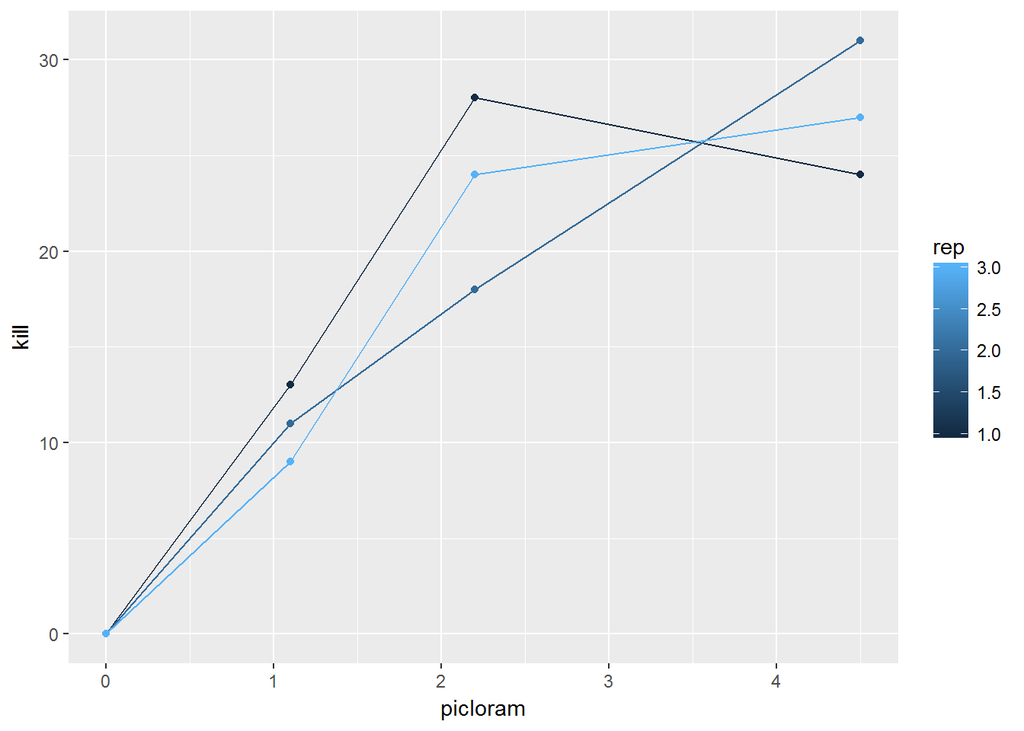

```r
# Generate predictions on the link scale
picloram_predict_2= predict(picloram_glm1,newdata=picloram_data, se.fit=TRUE,type="response")

## Construct confidence intervals
picloram_predict_2_ci=picloram_predict_2$fit +
1.96 * outer(picloram_predict_2$se.fit,c(-1,1))

ci <- data.frame(picloram = picloram_data$picloram, rep = picloram_data$rep, fit = picloram_glm1$fitted.values, ci_.25 = picloram_predict_2_ci[,1], ci_.95 = picloram_predict_2_ci[,2])

library(ggplot2)
# original data
ggplot(picloram_data, aes(x = picloram, y = kill, group = rep, color = rep)) + geom_line()+geom_point()
```

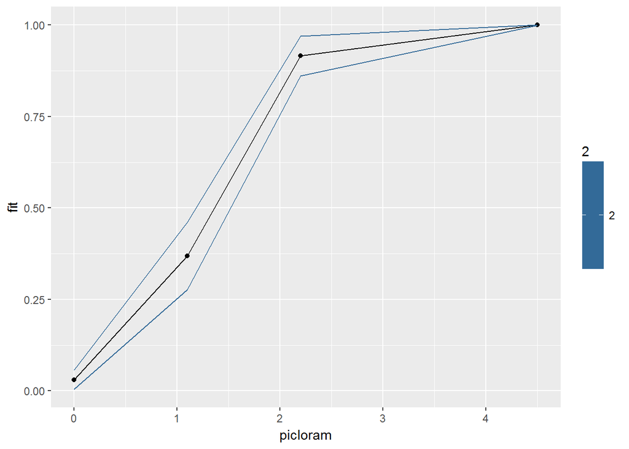

```r
# the fitted mean from the model including only picloram including pointwise 95% confidence intervals.
ggplot(ci, aes(x = picloram, y = fit, group = rep)) + geom_line()+geom_point()+geom_line(data = ci, aes(x = picloram,y = ci_.25, color = 2))+geom_line(data = ci, aes(x = picloram,y = ci_.95, color = 2))
```